# Lending Club Case Study

Kavish Shah

01/11/2021

## Case Study 1

```r
require(CatEncoders)
df <- read.csv("loans_full_schema.csv")


#Data Cleaning


#Drop emp_title as it has 4700+ categories

df <- subset(df, select = -emp_title)

#Label encoding

homeownership <- unique(df$homeownership)
lab_enc <- LabelEncoder.fit(homeownership)
df$homeownership <- transform(lab_enc, df$homeownership)


df$verification_income_joint[df$verification_income_joint == ""] <- NA

#verified_income_joint

for(i in 1:nrow(df)){

      if(is.na(df$verification_income_joint[i])){

          df$verification_income_joint[i] <- df$verified_income[i]


      } else { df$verification_income_joint[i] = df$verification_income_joint[i]}


}

verified_income_joint <- unique(df$verification_income_joint)
lab_enc_income_j <- LabelEncoder.fit(verified_income_joint)
df$verification_income_joint <- transform(lab_enc_income_j,df$verification_income_joint)


verified_income <- unique(df$verified_income)
lab_enc_income <- LabelEncoder.fit(verified_income)
df$verified_income <- transform(lab_enc_income,df$verified_income)

# Drop verified_income to avoid curse of multicollinearity
df <- subset(df, select = -verified_income)


loan_purpose <- unique(df$loan_purpose)
lab_enc_loan_purpose <- LabelEncoder.fit(loan_purpose)
df$loan_purpose <- transform(lab_enc_loan_purpose,df$loan_purpose)


application_type <- unique(df$application_type)
lab_enc_app_type <- LabelEncoder.fit(application_type)
df$application_type <- transform(lab_enc_app_type,df$application_type)

loan_status <- unique(df$loan_status)
lab_enc_ln_status <- LabelEncoder.fit(loan_status)
df$loan_status <- transform(lab_enc_ln_status,df$loan_status)


initial_listing_status <- unique(df$initial_listing_status)
lab_enc_ls <- LabelEncoder.fit(initial_listing_status)
df$initial_listing_status <- transform(lab_enc_ls,df$initial_listing_status)


disbursement_method <- unique(df$disbursement_method)
lab_enc_dsbm <- LabelEncoder.fit(disbursement_method)
df$disbursement_method <- transform(lab_enc_dsbm,df$disbursement_method)


#Appropriate Data Type conversion

fact_cols <- c("homeownership","verification_income_joint","loan_purpose",
                  "application_type","grade","sub_grade","loan_status"
               ,"initial_listing_status","disbursement_method")


df[,fact_cols] <- lapply(df[,fact_cols],as.factor)



#Dealing with Missing Data



#Annual Income Joint

for(i in 1:nrow(df)){

      if(is.na(df$annual_income_joint[i])){

          df$annual_income_joint[i] <- df$annual_income[i]


      } else { df$annual_income_joint[i] = df$annual_income_joint[i]}


}


#Drop Annual Income to prevent Multicollinearity


df <- subset(df, select = -annual_income)


#Debt to Income Ratio Joint

for(i in 1:nrow(df)){

      if(is.na(df$debt_to_income_joint[i])){

          df$debt_to_income_joint[i] <- df$debt_to_income[i]


      } else { df$debt_to_income_joint[i] = df$debt_to_income_joint[i]}


}


#Drop Debt to Income Ratio to prevent Multicollinearity


df <- subset(df, select = -debt_to_income)



#impute Q3 Value for emp_length

df$emp_length[is.na(df$emp_length)] <- 8.0

# impute Median Values for months_since_90d_late

summary(na.omit(df$months_since_90d_late))
```

```
##    Min. 1st Qu.  Median    Mean 3rd Qu.    Max.
##    2.00   29.00   47.00   46.11   63.00  128.00
```

```r
df$months_since_90d_late[is.na(df$months_since_90d_late)] <- 47.0


# impute Median Values for months_since_last_delinq

summary(na.omit(df$months_since_last_delinq))
```

```
##    Min. 1st Qu.  Median    Mean 3rd Qu.    Max.
##    1.00   19.00   34.00   36.76   53.00  118.00
```

```r
df$months_since_last_delinq[is.na(df$months_since_last_delinq)] <- 34.0


# impute Q1 Values for months_since_last_credit_inquiry

summary(na.omit(df$months_since_last_credit_inquiry))
```

```
##    Min. 1st Qu.  Median    Mean 3rd Qu.    Max.
##   0.000   2.000   6.000   7.341  11.000  24.000
```

```r
df$months_since_last_credit_inquiry[is.na(df$months_since_last_credit_inquiry)] <- 2.0


# Drop num_accounts_120d_past_due

df <- subset(df, select = -num_accounts_120d_past_due)



#Looking at the data profiling report obtained from Pandas Profiling


#Drop Skewed columns plagued with zeros


df <- subset(df, select = -c(delinq_2y,total_collection_amount_ever,
                             num_mort_accounts,tax_liens,paid_late_fees,
                             num_historical_failed_to_pay,
                             num_collections_last_12m,current_accounts_delinq,
                             num_accounts_30d_past_due))


#Remove columns which are highly correlated with each other


df <- subset(df, select = -c(total_credit_lines,num_open_cc_accounts,
                             num_satisfactory_accounts,total_credit_lines,
                             open_credit_lines,total_credit_lines,
                             total_credit_utilized,num_satisfactory_accounts))


#write.csv(df,filename="CleanedLCData.csv)
```

## Data Visualization

-Plotted a few variables against Interest rates to better understand their behavior.

```r
#DATA VIZ

require(ggplot2)
require(choroplethr)
require(choroplethrMaps)
require(dplyr)

dataviz <- read.csv("CleanedLCData.csv")
dataviz <- subset(dataviz, select = c(interest_rate, total_credit_utilized, debt_to_income_joint,
                                      grade, sub_grade, inquiries_last_12m, total_debit_limit))
dataviz1 <- dataviz %>% group_by(interest_rate) %>% summarise(total_credit_utilized=mean(total_credit_utilized))
dataviz2 <- dataviz %>% group_by(interest_rate) %>% summarise(debt_to_income_joint=mean(debt_to_income_joint))
dataviz3 <- dataviz %>% group_by(interest_rate) %>% summarise(inquiries_last_12m=mean(inquiries_last_12m))
dataviz4 <- dataviz %>% group_by(interest_rate) %>% summarise(total_debit_limit=mean(total_debit_limit))
ogdata <-read.csv("loans_full_schema.csv")
```

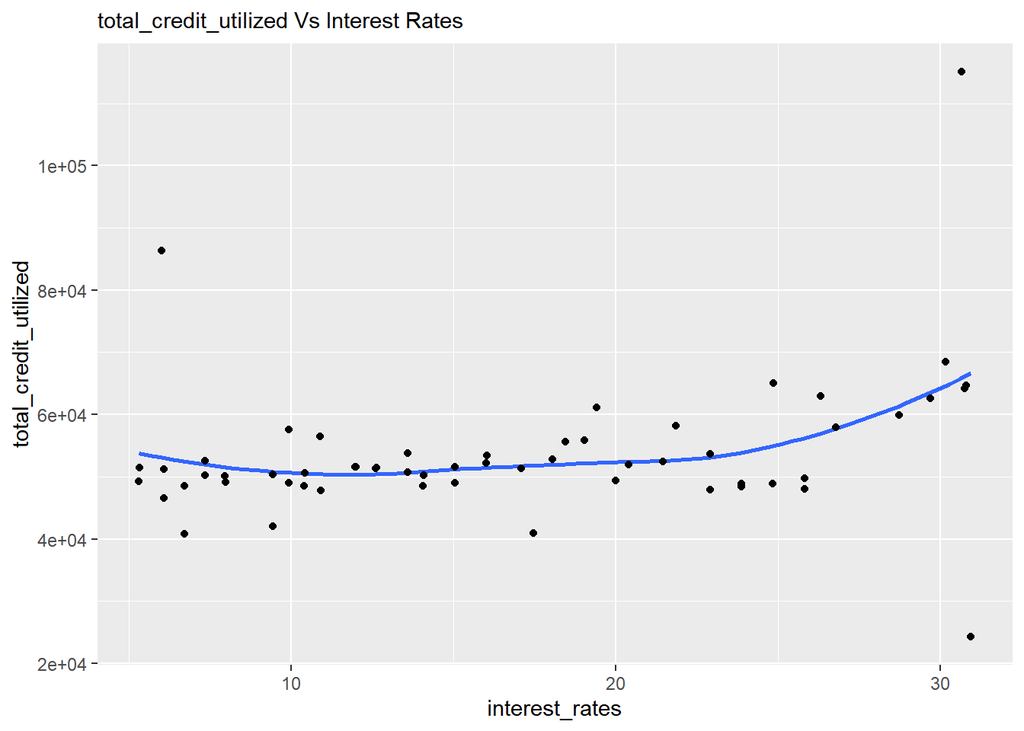

```r
library(ggplot2)
data(dataviz, package = "ggplot2")


# Scatterplot
totalcredvsIR <- ggplot(dataviz1, aes(y=total_credit_utilized, x=interest_rate)) +
        geom_smooth(method="loess", se=F) +
        geom_point() +
        labs(subtitle="total_credit_utilized Vs Interest Rates",
             x="interest_rates",
             y="total_credit_utilized")
plot(totalcredvsIR)
```

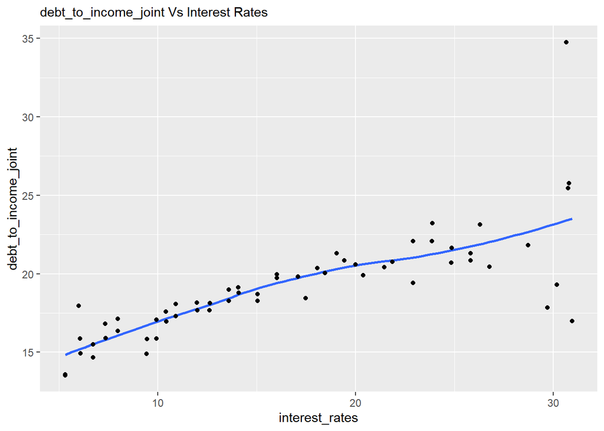

```r
dtivsIR <- ggplot(dataviz2, aes(y=debt_to_income_joint, x=interest_rate)) +
        geom_smooth(method="loess", se=F) +
        geom_point() +
        labs(subtitle="debt_to_income_joint Vs Interest Rates",
             x="interest_rates",
             y="debt_to_income_joint")
plot(dtivsIR)
```

Debt to income ratio (joint) is directly related to interest rate.

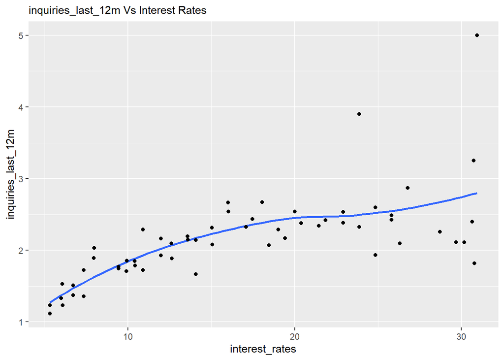

```r
inquiriesvsIR <- ggplot(dataviz3, aes(y=inquiries_last_12m, x=interest_rate)) +
        geom_smooth(method="loess", se=F) +
        geom_point() +
        labs(subtitle="inquiries_last_12m Vs Interest Rates",
             x="interest_rates",
             y="inquiries_last_12m")
plot(inquiriesvsIR)
```

Borrowers with more inquiries in the lat 12 months are more likely to be charged a higher interest rate.

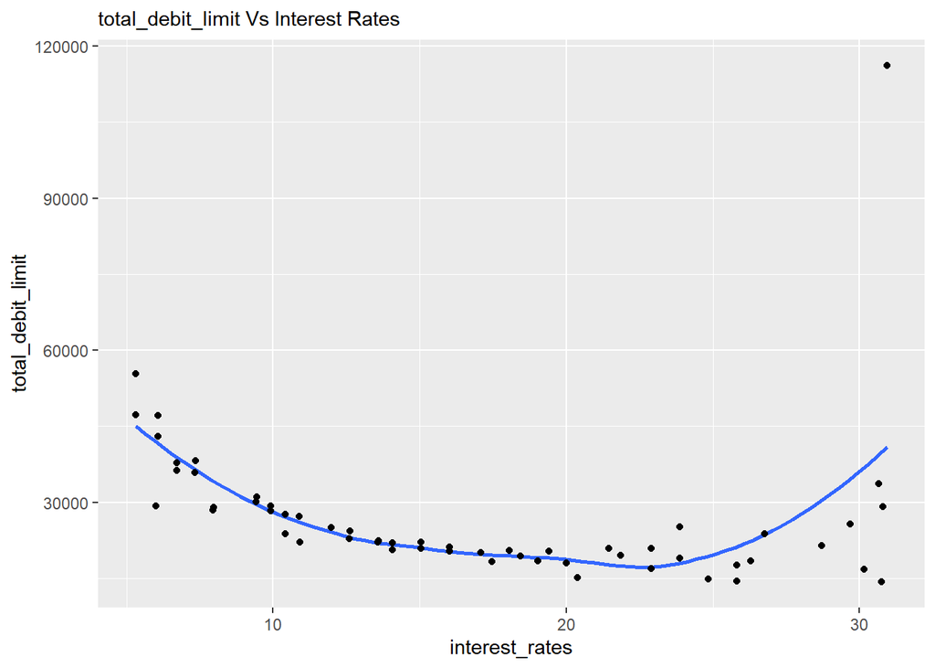

```r
debitlimvsIR <- ggplot(dataviz4, aes(y=total_debit_limit, x=interest_rate)) +
        geom_smooth(method="loess", se=F) +
        geom_point() +
        labs(subtitle="total_debit_limit Vs Interest Rates",
             x="interest_rates",
             y="total_debit_limit")
plot(debitlimvsIR)
```

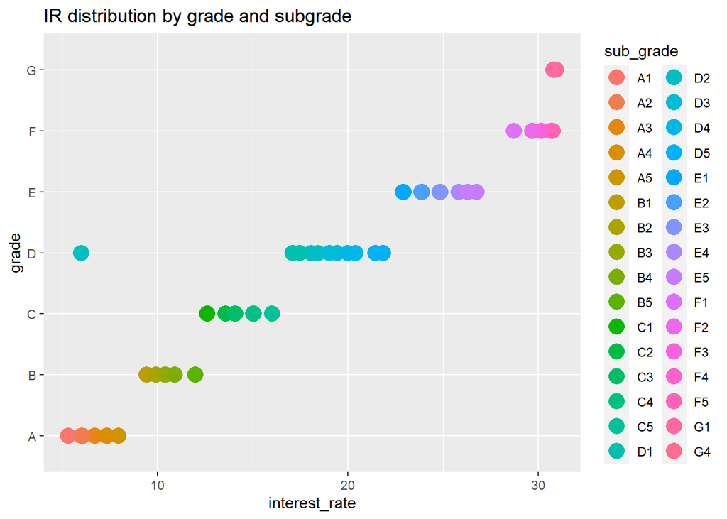

```r
##scatbox grade vs IR
ggplot(dataviz, aes(x = interest_rate,
                     y = grade,
                     color=sub_grade)) +
        geom_point(size=5) +
        labs(title = "IR distribution by grade and subgrade")
```

This is a direct indication that interest rates are directly dictated by loan grades and subgrades.

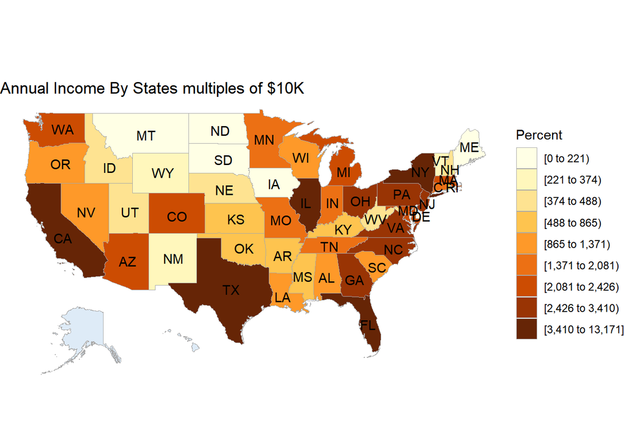

```r
df_viz <- data.frame(cbind(df$state,df$annual_income_joint))

names(df_viz) <- c("region","value")

df_viz$value <- as.numeric(df_viz$value)

df_viz <- df_viz %>% group_by(region) %>% summarise(value=sum(value))


#Data For Iowa is Missing

new_row <- c("ia",0)

df_viz <- rbind(df_viz[1:12, ],new_row,df_viz[- (1:12), ])

data("state.regions")
df_viz$region <- state.regions$region
df_viz$abb <- state.regions$abb
df_viz$fips.numeric <- state.regions$fips.numeric
df_viz$fips.character <- state.regions$fips.character
df_viz$value <- as.numeric(df_viz$value)
df_viz$value <- df_viz$value / 10000


# create the map
state_choropleth(df_viz,num_colors=9) +
  scale_fill_brewer(palette="YlOrBr") +
  labs(title = "Annual Income By States multiples of $10K",
       fill = "Percent")
```

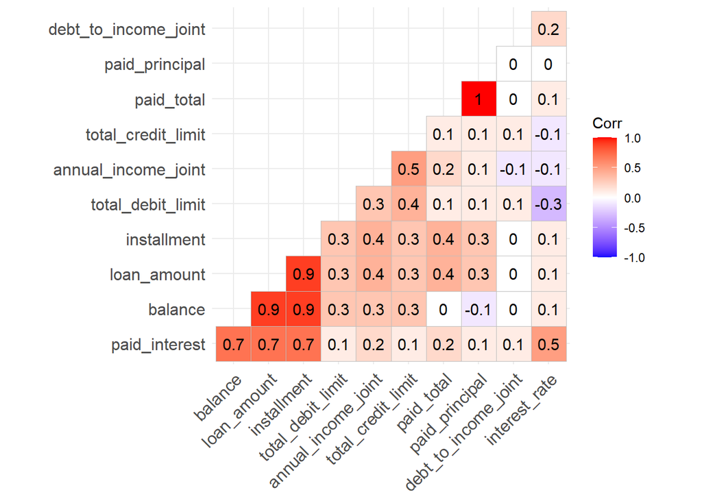

```r
require(ggcorrplot)

df_pairs <- select_if(df,is.numeric)

df_pairs <- subset(df_pairs, select = c(annual_income_joint,
                                        debt_to_income_joint,
                                        total_credit_limit,
                                        total_debit_limit,loan_amount,
                                        interest_rate,installment,
                                        balance,paid_total,paid_principal,
                                        paid_interest))


r <- round(cor(df_pairs, use="complete.obs"),1)


ggcorrplot(r,hc.order = TRUE,type = "lower",lab = TRUE)
```

# Machine Learning

## Approach 1

### Linear regression

Linear regression.

We evaluate the models based on Train Mean Squared Error, Test Mean Squared Error and $Adjusted R^{2}$

```r
require(caTools)
set.seed(101)

# Remove columns with High cardinality
df <- subset(df, select = -c(state,earliest_credit_line,issue_month))


summary(df)
```

```
##    emp_length     homeownership annual_income_joint verification_income_joint
##  Min.   : 0.000   1:4789        Min.   :   5235     1:3822
##  1st Qu.: 3.000   2:1353        1st Qu.:  50000     2:4009
##  Median : 7.000   3:3858        Median :  75000     3:2169
##  Mean   : 6.099                 Mean   :  89138
##  3rd Qu.:10.000                 3rd Qu.: 108000
##  Max.   :10.000                 Max.   :2300000
##
##  debt_to_income_joint months_since_last_delinq inquiries_last_12m
##  Min.   : 0.00        Min.   :  1.0            Min.   : 0.000
##  1st Qu.:11.20        1st Qu.: 34.0            1st Qu.: 0.000
##  Median :17.32        Median : 34.0            Median : 1.000
##  Mean   :17.73        Mean   : 35.2            Mean   : 1.958
##  3rd Qu.:23.82        3rd Qu.: 34.0            3rd Qu.: 3.000
##  Max.   :39.99        Max.   :118.0            Max.   :29.000
##
##  total_credit_limit months_since_90d_late current_installment_accounts
##  Min.   :      0    Min.   :  2.0         Min.   : 0.000
##  1st Qu.:  51594    1st Qu.: 47.0         1st Qu.: 1.000
##  Median : 114667    Median : 47.0         Median : 2.000
##  Mean   : 183606    Mean   : 46.8         Mean   : 2.664
##  3rd Qu.: 267550    3rd Qu.: 47.0         3rd Qu.: 3.000
##  Max.   :3386034    Max.   :128.0         Max.   :35.000
##
##  accounts_opened_24m months_since_last_credit_inquiry num_active_debit_accounts
##  Min.   : 0.000      Min.   : 0.000                   Min.   : 0.000
##  1st Qu.: 2.000      1st Qu.: 2.000                   1st Qu.: 2.000
##  Median : 4.000      Median : 5.000                   Median : 3.000
##  Mean   : 4.376      Mean   : 6.662                   Mean   : 3.595
##  3rd Qu.: 6.000      3rd Qu.:10.000                   3rd Qu.: 5.000
##  Max.   :29.000      Max.   :24.000                   Max.   :32.000
##
##  total_debit_limit num_total_cc_accounts num_cc_carrying_balance
##  Min.   :     0    Min.   : 2.00         Min.   : 0.000
##  1st Qu.: 10000    1st Qu.: 7.00         1st Qu.: 3.000
##  Median : 19500    Median :11.00         Median : 5.000
##  Mean   : 27357    Mean   :13.03         Mean   : 5.231
##  3rd Qu.: 36100    3rd Qu.:17.00         3rd Qu.: 7.000
##  Max.   :386700    Max.   :66.00         Max.   :43.000
##
```

[output cut: 25 more lines]

```
##  1:9284              Min.   :    0   Min.   :    0.0   Min.   :    0.0
##  2: 716              1st Qu.: 6679   1st Qu.:  928.7   1st Qu.:  587.1
##                      Median :12380   Median : 1563.3   Median :  985.0
##                      Mean   :14459   Mean   : 2494.2   Mean   : 1894.5
##                      3rd Qu.:20690   3rd Qu.: 2616.0   3rd Qu.: 1694.6
##                      Max.   :40000   Max.   :41630.4   Max.   :40000.0
##
##  paid_interest
##  Min.   :   0.0
##  1st Qu.: 221.8
##  Median : 446.1
##  Mean   : 599.7
##  3rd Qu.: 825.4
##  Max.   :4216.4
##
```

```r
#Train-Test Split, 65% SplitRatio

sample <- sample.split(df$interest_rate, SplitRatio = 0.65)

df.train <- subset(df,sample == T)
df.test <- subset(df,sample == F)

train <- df.train
test <- df.test

ir_lm <- lm(interest_rate~., data = train)
summary(ir_lm)
```

```
##
## Call:
## lm(formula = interest_rate ~ ., data = train)
##
## Residuals:
##      Min       1Q   Median       3Q      Max
## -12.1360  -0.0190  -0.0004   0.0155   0.3284
##
## Coefficients: (6 not defined because of singularities)
##                                    Estimate Std. Error  t value Pr(>|t|)
## (Intercept)                       5.241e+00  1.918e-01   27.333  < 2e-16 ***
## emp_length                        5.175e-04  6.195e-04    0.835  0.40358
## homeownership2                    9.158e-03  6.719e-03    1.363  0.17291
## homeownership3                    6.141e-03  5.491e-03    1.118  0.26344
## annual_income_joint               7.515e-08  4.150e-08    1.811  0.07018 .
## verification_income_joint2       -6.918e-03  4.976e-03   -1.390  0.16450
## verification_income_joint3        9.471e-04  6.154e-03    0.154  0.87769
## debt_to_income_joint              1.865e-04  2.978e-04    0.626  0.53115
## months_since_last_delinq          1.708e-04  1.735e-04    0.984  0.32506
## inquiries_last_12m               -2.724e-04  1.058e-03   -0.257  0.79684
## total_credit_limit               -1.440e-08  1.625e-08   -0.886  0.37551
## months_since_90d_late            -1.642e-04  2.357e-04   -0.697  0.48611
## current_installment_accounts      1.057e-04  7.953e-04    0.133  0.89429
## accounts_opened_24m               4.225e-04  8.584e-04    0.492  0.62258
## months_since_last_credit_inquiry -8.264e-04  3.930e-04   -2.103  0.03553 *
## num_active_debit_accounts        -8.688e-04  1.884e-03   -0.461  0.64470
## total_debit_limit                 2.608e-08  1.227e-07    0.213  0.83169
## num_total_cc_accounts             1.312e-04  3.947e-04    0.332  0.73953
## num_cc_carrying_balance          -7.431e-04  1.429e-03   -0.520  0.60306
## account_never_delinq_percent     -6.829e-06  2.442e-04   -0.028  0.97769
## public_record_bankrupt            2.604e-03  6.449e-03    0.404  0.68639
## loan_purpose2                     3.850e-04  1.882e-02    0.020  0.98368
## loan_purpose3                     7.625e-03  1.848e-02    0.413  0.67998
## loan_purpose4                     1.130e-02  2.004e-02    0.564  0.57289
## loan_purpose5                     5.180e-03  2.526e-02    0.205  0.83749
## loan_purpose6                     1.994e-02  2.189e-02    0.911  0.36245
## loan_purpose7                     1.458e-02  2.462e-02    0.592  0.55384
## loan_purpose8                     4.277e-03  3.057e-02    0.140  0.88875
## loan_purpose9                     8.456e-03  1.945e-02    0.435  0.66379
## loan_purpose10                    4.965e-02  7.806e-02    0.636  0.52479
```

[output cut: 45 more lines]

```
## loan_status4                     -1.790e-02  1.903e-01   -0.094  0.92508
## loan_status5                     -4.032e-02  1.915e-01   -0.211  0.83323
## loan_status6                     -7.348e-02  1.905e-01   -0.386  0.69974
## initial_listing_status2           1.557e-02  5.928e-03    2.627  0.00863 **
## disbursement_method2              3.983e-03  8.837e-03    0.451  0.65222
## balance                           1.636e-06  1.258e-05    0.130  0.89653
## paid_total                       -4.189e-04  1.208e-03   -0.347  0.72871
## paid_principal                    4.184e-04  1.208e-03    0.346  0.72899
## paid_interest                     3.506e-04  1.208e-03    0.290  0.77160
## ---
## Signif. codes:  0 '***' 0.001 '**' 0.01 '*' 0.05 '.' 0.1 ' ' 1
##
## Residual standard error: 0.1689 on 6422 degrees of freedom
## Multiple R-squared:  0.9989, Adjusted R-squared:  0.9989
## F-statistic: 7.394e+04 on 77 and 6422 DF,  p-value: < 2.2e-16
```

```r
#NAs in Summary of linear model mean the presence of a rank deficient matrix

lm_train_pred <- predict(ir_lm,train)
lm_test_pred <- predict(ir_lm, test)

lm_train_mse <- mean((train$interest_rate - lm_train_pred)^2)
cat("Train MSE of Linear Regression is:", lm_train_mse,'\n')
```

```
## Train MSE of Linear Regression is: 0.02818039
```

```r
lm_test_mse <- mean((test$interest_rate - lm_test_pred)^2)
cat("Test MSE of Linear Regression is:", lm_test_mse,'\n')
```

```
## Test MSE of Linear Regression is: 0.06263831
```

```r
cat("Adjusted R^2 of Linear Regression is: ",0.9989,'\n')
```

```
## Adjusted R^2 of Linear Regression is:  0.9989
```

### Gradient Boosting Methods

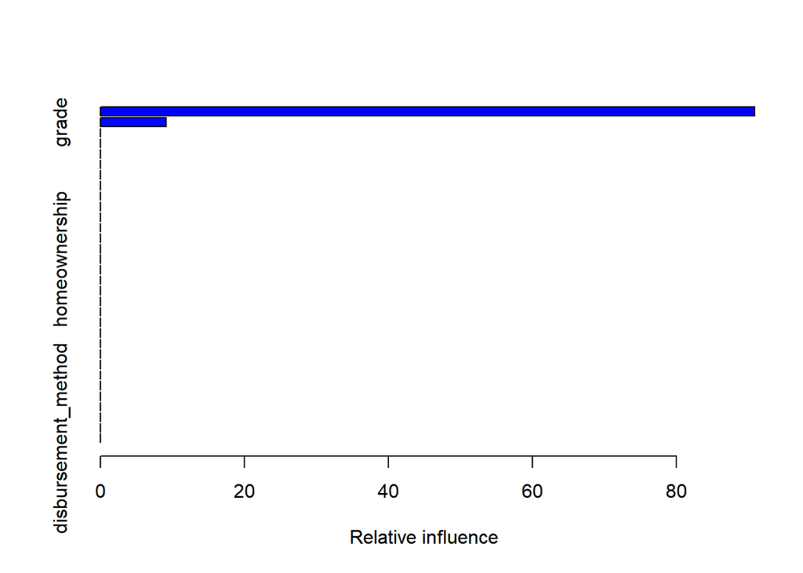

```
##                                                               var      rel.inf
## sub_grade                                               sub_grade 9.089148e+01
## grade                                                       grade 9.098582e+00
## months_since_last_credit_inquiry months_since_last_credit_inquiry 5.593954e-03
## num_cc_carrying_balance                   num_cc_carrying_balance 2.195425e-03
## paid_principal                                     paid_principal 5.264688e-04
## paid_interest                                       paid_interest 3.339636e-04
## months_since_last_delinq                 months_since_last_delinq 3.031025e-04
## paid_total                                             paid_total 2.982574e-04
## num_active_debit_accounts               num_active_debit_accounts 2.302856e-04
## initial_listing_status                     initial_listing_status 1.823020e-04
## balance                                                   balance 1.613274e-04
## total_credit_limit                             total_credit_limit 8.669551e-05
## annual_income_joint                           annual_income_joint 3.130999e-05
## emp_length                                             emp_length 0.000000e+00
## homeownership                                       homeownership 0.000000e+00
## verification_income_joint               verification_income_joint 0.000000e+00
## debt_to_income_joint                         debt_to_income_joint 0.000000e+00
## inquiries_last_12m                             inquiries_last_12m 0.000000e+00
## months_since_90d_late                       months_since_90d_late 0.000000e+00
## current_installment_accounts         current_installment_accounts 0.000000e+00
## accounts_opened_24m                           accounts_opened_24m 0.000000e+00
## total_debit_limit                               total_debit_limit 0.000000e+00
## num_total_cc_accounts                       num_total_cc_accounts 0.000000e+00
## account_never_delinq_percent         account_never_delinq_percent 0.000000e+00
## public_record_bankrupt                     public_record_bankrupt 0.000000e+00
## loan_purpose                                         loan_purpose 0.000000e+00
## application_type                                 application_type 0.000000e+00
## loan_amount                                           loan_amount 0.000000e+00
## term                                                         term 0.000000e+00
## installment                                           installment 0.000000e+00
## loan_status                                           loan_status 0.000000e+00
## disbursement_method                           disbursement_method 0.000000e+00
```

```r
require(gbm)
ir_gbm <- gbm(interest_rate ~ ., data = train, distribution = "gaussian"
                 ,n.trees = 1000, shrinkage = 0.05)
summary(ir_gbm)
```

```r
gbm_train_pred <- predict(ir_gbm, train, n.trees = 1000)
gbm_test_pred <- predict(ir_gbm, test, n.trees = 1000)

ir_gbm_train_MSE <- mean((train$interest_rate - gbm_train_pred)^2)
cat("Training MSE of boosted tree is:", ir_gbm_train_MSE,'\n')
```

```
## Training MSE of boosted tree is: 0.02818219
```

```r
ir_gbm_test_MSE <- mean((test$interest_rate - gbm_test_pred)^2)
cat("Test MSE of boosted tree is:", ir_gbm_test_MSE,'\n')
```

```
## Test MSE of boosted tree is: 0.06295111
```

```r
sse_gbm <- sum((test$interest_rate-gbm_test_pred)^2)
sst_gbm <- sum((mean(test$interest_rate)-test$interest_rate)^2)
gbm_r2 <- 1 - (sse_gbm/sst_gbm)
cat("R^2 for Boosted model:", gbm_r2)
```

```
## R^2 for Boosted model: 0.9974822
```

From the summary of both the models, it is evident that grade and sub_grade are the most important features when it comes to predicting the interest rates.

This is expected because the features grade and sub-grade for an observation essentially bucket the creditors according to their risk profiles. Interest rate for each creditor is dictated by their risk profiles. For a creditor with poor credit and a history of defaults, Lending Club is exposed to unwanted risk and the propensity of default, hence the higher interest rates. The converse of this statement also holds true: lower interest rates for creditors with good credit and low default-risk.

## Approach 2

Exploring the relationship between variables and interest rates with grade and sub_grade features removed.

```r
new_df <- subset(df, select = -c(grade,sub_grade))


sample1 <- sample.split(new_df$interest_rate, SplitRatio = 0.65)

df.train1 <- subset(new_df,sample1 == T)
df.test1 <- subset(new_df,sample1 == F)

train1 <- df.train1
test1 <- df.test1


ir_lm1 <- lm(interest_rate~., data = train1)
summary(ir_lm1)
```

```
##
## Call:
## lm(formula = interest_rate ~ ., data = train1)
##
## Residuals:
##     Min      1Q  Median      3Q     Max
## -7.0854 -1.8665 -0.4042  1.4456 16.5020
##
## Coefficients:
##                                    Estimate Std. Error t value Pr(>|t|)
## (Intercept)                       4.298e+00  2.705e+00   1.589 0.112165
## emp_length                       -2.373e-02  9.886e-03  -2.401 0.016395 *
## homeownership2                    1.696e-01  1.085e-01   1.563 0.118033
## homeownership3                    4.619e-01  8.792e-02   5.254 1.54e-07 ***
## annual_income_joint               1.289e-06  6.834e-07   1.886 0.059332 .
## verification_income_joint2        6.089e-01  7.908e-02   7.700 1.56e-14 ***
## verification_income_joint3        1.233e+00  9.607e-02  12.836  < 2e-16 ***
## debt_to_income_joint              6.254e-02  4.653e-03  13.440  < 2e-16 ***
## months_since_last_delinq         -9.753e-03  2.762e-03  -3.531 0.000416 ***
## inquiries_last_12m                8.036e-02  1.703e-02   4.717 2.44e-06 ***
## total_credit_limit               -1.023e-06  2.719e-07  -3.763 0.000170 ***
## months_since_90d_late             1.142e-03  3.775e-03   0.303 0.762172
## current_installment_accounts     -5.188e-02  1.279e-02  -4.055 5.08e-05 ***
## accounts_opened_24m               1.089e-01  1.362e-02   7.992 1.57e-15 ***
## months_since_last_credit_inquiry -4.089e-03  6.230e-03  -0.656 0.511605
## num_active_debit_accounts         7.356e-02  3.056e-02   2.407 0.016115 *
## total_debit_limit                -1.986e-05  1.929e-06 -10.294  < 2e-16 ***
## num_total_cc_accounts            -5.966e-02  6.242e-03  -9.557  < 2e-16 ***
## num_cc_carrying_balance           8.540e-02  2.304e-02   3.706 0.000212 ***
## account_never_delinq_percent     -3.581e-02  3.868e-03  -9.257  < 2e-16 ***
## public_record_bankrupt           -9.566e-02  1.015e-01  -0.943 0.345933
## loan_purpose2                    -4.145e-01  3.065e-01  -1.352 0.176320
## loan_purpose3                     3.826e-02  3.018e-01   0.127 0.899110
## loan_purpose4                    -2.707e-01  3.259e-01  -0.831 0.406190
## loan_purpose5                    -3.362e-01  4.122e-01  -0.816 0.414813
## loan_purpose6                    -2.549e-01  3.540e-01  -0.720 0.471533
## loan_purpose7                     1.509e-01  4.007e-01   0.377 0.706517
## loan_purpose8                     3.774e-01  5.152e-01   0.733 0.463802
## loan_purpose9                     1.348e-01  3.162e-01   0.426 0.669812
## loan_purpose10                    4.331e-01  9.099e-01   0.476 0.634112
```

[output cut: 8 more lines]

```
## loan_status4                     -1.915e+00  2.685e+00  -0.713 0.475754
## loan_status5                     -3.203e-01  2.711e+00  -0.118 0.905925
## loan_status6                      2.203e+00  2.681e+00   0.822 0.411323
## initial_listing_status2          -1.172e+00  9.207e-02 -12.726  < 2e-16 ***
## disbursement_method2             -1.292e+00  1.354e-01  -9.541  < 2e-16 ***
## balance                           7.269e-05  2.201e-04   0.330 0.741243
## paid_total                       -2.372e-02  1.891e-02  -1.255 0.209693
## paid_principal                    2.380e-02  1.891e-02   1.259 0.208171
## paid_interest                     2.872e-02  1.891e-02   1.519 0.128860
## ---
## Signif. codes:  0 '***' 0.001 '**' 0.01 '*' 0.05 '.' 0.1 ' ' 1
##
## Residual standard error: 2.712 on 6453 degrees of freedom
## Multiple R-squared:  0.708,  Adjusted R-squared:  0.7059
## F-statistic: 340.1 on 46 and 6453 DF,  p-value: < 2.2e-16
```

```r
lm_train_pred1 <- predict(ir_lm1,train1)
lm_test_pred1 <- predict(ir_lm1, test1)

lm_train_mse1 <- mean((train1$interest_rate - lm_train_pred1)^2)
cat("Train MSE of Linear Regression is:", lm_train_mse1,'\n')
```

```
## Train MSE of Linear Regression is: 7.303383
```

```r
lm_test_mse1 <- mean((test1$interest_rate - lm_test_pred1)^2)
cat("Test MSE of Linear Regression is:", lm_test_mse1,'\n')
```

```
## Test MSE of Linear Regression is: 7.519474
```

```r
cat("Adjusted R^2 of Linear Regression is: ",0.7059,'\n')
```

```
## Adjusted R^2 of Linear Regression is:  0.7059
```

### Gradient Boosting Methods

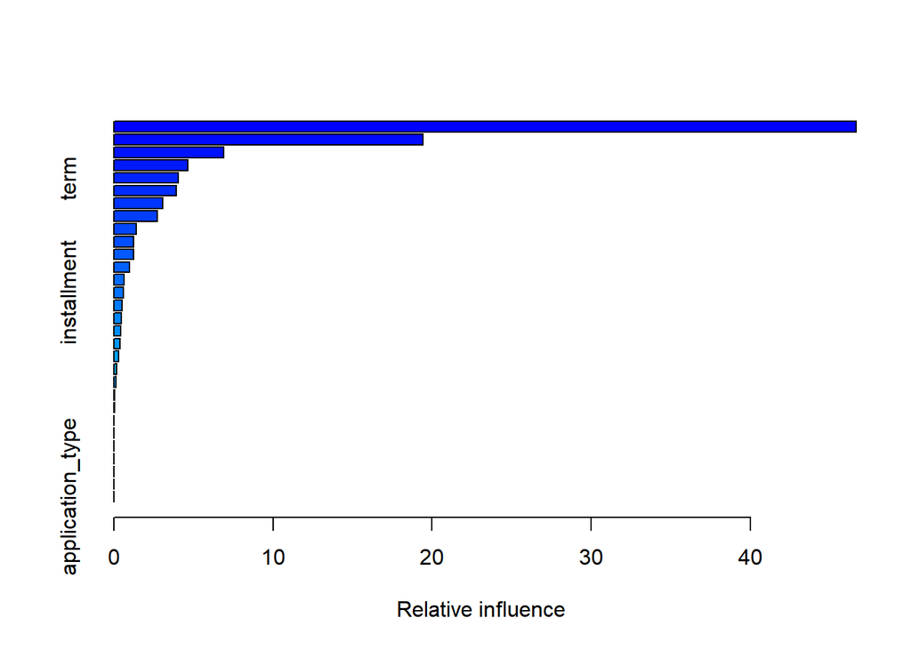

```
##                                                               var     rel.inf
## paid_interest                                       paid_interest 46.63388861
## paid_principal                                     paid_principal 19.40727014
## total_debit_limit                               total_debit_limit  6.90619969
## balance                                                   balance  4.62590238
## term                                                         term  4.03077517
## loan_status                                           loan_status  3.90834972
## loan_amount                                           loan_amount  3.05895211
## debt_to_income_joint                         debt_to_income_joint  2.74754132
## initial_listing_status                     initial_listing_status  1.40840143
## total_credit_limit                             total_credit_limit  1.23358356
## paid_total                                             paid_total  1.22495883
## verification_income_joint               verification_income_joint  0.98169658
## num_active_debit_accounts               num_active_debit_accounts  0.65188692
## installment                                           installment  0.59401455
## accounts_opened_24m                           accounts_opened_24m  0.52187354
## disbursement_method                           disbursement_method  0.48908396
## inquiries_last_12m                             inquiries_last_12m  0.41081325
## num_cc_carrying_balance                   num_cc_carrying_balance  0.40924602
## account_never_delinq_percent         account_never_delinq_percent  0.32020095
## months_since_last_delinq                 months_since_last_delinq  0.16920944
## loan_purpose                                         loan_purpose  0.13047755
## annual_income_joint                           annual_income_joint  0.06103304
## homeownership                                       homeownership  0.05817431
## num_total_cc_accounts                       num_total_cc_accounts  0.01646694
## emp_length                                             emp_length  0.00000000
## months_since_90d_late                       months_since_90d_late  0.00000000
## current_installment_accounts         current_installment_accounts  0.00000000
## months_since_last_credit_inquiry months_since_last_credit_inquiry  0.00000000
## public_record_bankrupt                     public_record_bankrupt  0.00000000
## application_type                                 application_type  0.00000000
```

```r
ir_gbm1 <- gbm(interest_rate ~ ., data = train1, distribution = "gaussian"
                 ,n.trees = 1000, shrinkage = 0.05)
summary(ir_gbm1)
```

```r
gbm_train_pred1 <- predict(ir_gbm1, train1, n.trees = 1000)
gbm_test_pred1 <- predict(ir_gbm1, test1, n.trees = 1000)

ir_gbm_train_MSE1 <- mean((train1$interest_rate - gbm_train_pred1)^2)
cat("Training MSE of boosted tree is:", ir_gbm_train_MSE1,'\n')
```

```
## Training MSE of boosted tree is: 5.317097
```

```r
ir_gbm_test_MSE1 <- mean((test1$interest_rate - gbm_test_pred1)^2)
cat("Test MSE of boosted tree is:", ir_gbm_test_MSE1,'\n')
```

```
## Test MSE of boosted tree is: 5.884052
```

```r
sse_gbm1 <- sum((test1$interest_rate-gbm_test_pred1)^2)
sst_gbm1 <- sum((mean(test1$interest_rate)-test1$interest_rate)^2)
gbm_1_r2 <- 1 - (sse_gbm1/sst_gbm1)
cat("R^2 for Boosted model:", gbm_1_r2)
```

```
## R^2 for Boosted model: 0.7646563
```

GBM performs better than the Linear regression model in terms of Train MSE, Test MSE and $Adjusted R^{2}$

### Enhancements to the GBM Model

Try different tree values to achieve lowest possible test error

```r
trees <- c(500,750,1000,1500,2000)
length.trees <- length(trees)

gbm_train_errors_t <- rep(-1, length.trees)
gbm_test_errors_t <- rep(-1, length.trees)

for (i in 1:length.trees){
gbm_t <- gbm(interest_rate ~ ., data = train1, distribution = "gaussian"
                 ,n.trees = trees[i], shrinkage = 0.05)
gbm_train_pred_t <- predict(gbm_t, train1)
gbm_test_pred_t <- predict(gbm_t, test1)
gbm_train_errors_t[i]<-mean((train1$interest_rate- gbm_train_pred_t)^2)
gbm_test_errors_t[i] <- mean((test1$interest_rate - gbm_test_pred_t)^2)
}
```

```
## Using 500 trees...
##
## Using 500 trees...
```

```
## Using 750 trees...
##
## Using 750 trees...
```

```
## Using 1000 trees...
##
## Using 1000 trees...
```

```
## Using 1500 trees...
##
## Using 1500 trees...
```

```
## Using 2000 trees...
##
## Using 2000 trees...
```

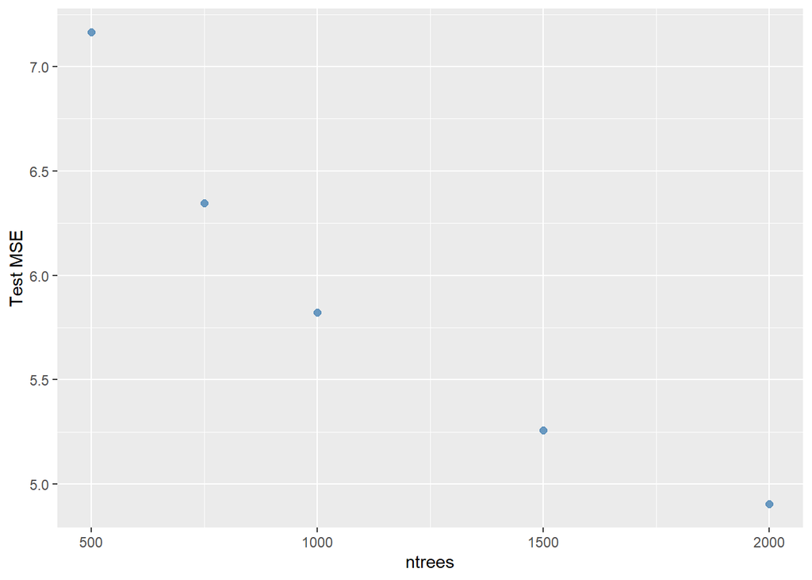

```r
ggplot(data.frame(x=trees, y=gbm_test_errors_t), aes(x=x, y=y))+
               xlab("ntrees") + ylab("Test MSE")+
               geom_point(color="steelblue", size = 2, alpha=.8)
```

```r
min(gbm_test_errors_t)
```

```
## [1] 4.903257
```

```r
trees[which.min(gbm_test_errors_t)]
```

```
## [1] 2000
```

We fix n.trees to 2000 and try different values of shrinkage($\lambda$) parameter

```r
lambdas <- seq(0.01,0.10,by=0.01)
length.shrinkage <- length(lambdas)

gbm_train_errors_s <- rep(-1, length.shrinkage)
gbm_test_errors_s <- rep(-1, length.shrinkage)

for (i in 1:length.shrinkage){
gbm_s <- gbm(interest_rate ~ ., data = train1, distribution = "gaussian"
                 ,n.trees = 2000, shrinkage = lambdas[i])
gbm_train_pred_s <- predict(gbm_s, train1)
gbm_test_pred_s <- predict(gbm_s, test1)
gbm_train_errors_s[i]<-mean((train1$interest_rate - gbm_train_pred_s)^2)
gbm_test_errors_s[i] <- mean((test1$interest_rate - gbm_test_pred_s)^2)
}
```

[output not shown]

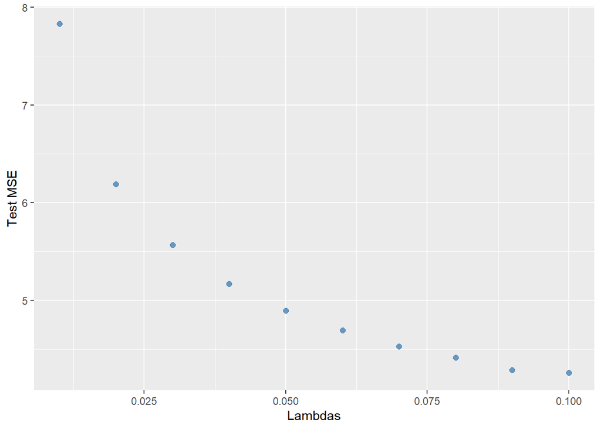

```r
ggplot(data.frame(x=lambdas, y=gbm_test_errors_s), aes(x=x, y=y))+
               xlab("Lambdas") + ylab("Test MSE")+
               geom_point(color="steelblue", size = 2, alpha=.8)
```

```r
min(gbm_test_errors_s)
```

```
## [1] 4.254482
```

```r
lambdas[which.min(gbm_test_errors_s)]
```

```
## [1] 0.1
```

K-Fold Cross Validation for GBM model with $\lambda = 0.10$ and $n.tree=2000$

```r
gbm_cv <- gbm(interest_rate ~ .,data = train1, distribution = "gaussian"
                 ,n.trees = 2000, shrinkage = 0.10,cv.folds=10)

gbmcv_train_pred <- predict(gbm_cv, train1)
```

```
## Using 2000 trees...
```

```r
gbmcv_test_pred <- predict(gbm_cv, test1)
```

```
## Using 2000 trees...
```

```r
gbmcv_train_errors2 <- mean((train1$interest_rate - gbmcv_train_pred)^2)

gbmcv_test_errors <- mean((test1$interest_rate - gbmcv_test_pred)^2)
cat("Test MSE for GBM CV:",gbmcv_test_errors)
```

```
## Test MSE for GBM CV: 4.172739
```

```r
sse_gbmcv <- sum((test1$interest_rate-gbmcv_test_pred)^2)
sst_gbmcv <- sum((mean(test1$interest_rate)-test1$interest_rate)^2)
gbmcv_r2 <- 1 - (sse_gbmcv/sst_gbmcv)
cat("R^2 for GBM CV:", gbmcv_r2)
```

```
## R^2 for GBM CV: 0.8331035
```

Visualize Test Results

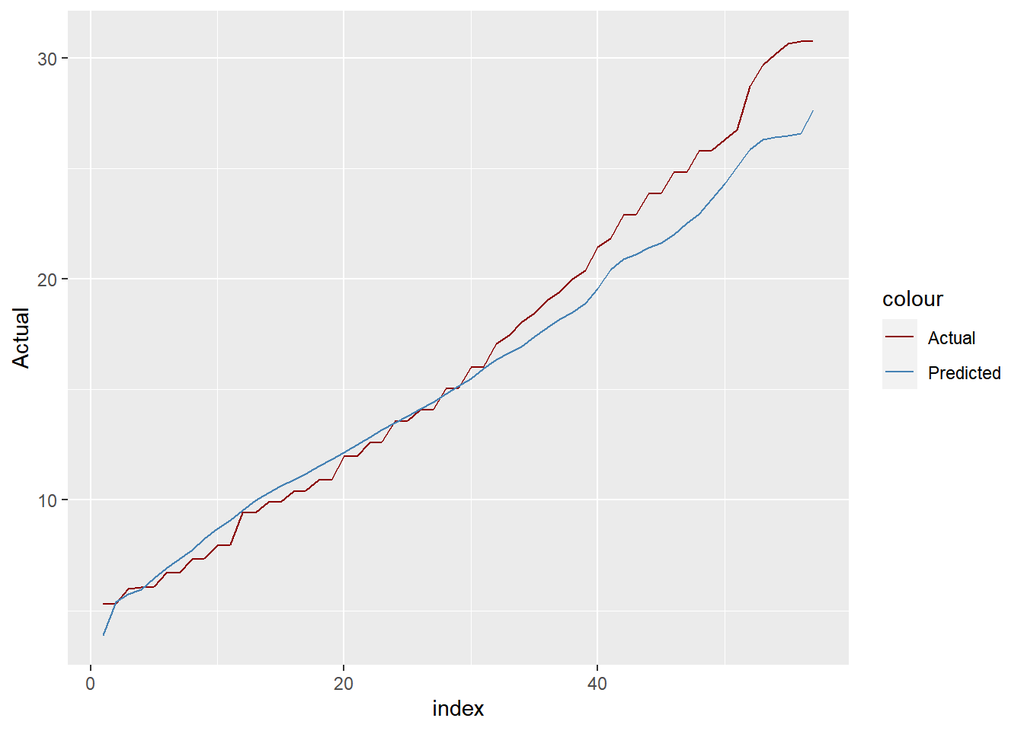

```r
library(ggplot2)

idx <- seq(1,length(test1$interest_rate))
predictions <- data.frame(idx,sort(gbmcv_test_pred),sort(test1$interest_rate))

predictions1 <- predictions %>% group_by(sort.test1.interest_rate.) %>% summarise_each(funs(mean))
predictions1$idx <- seq(1,nrow(predictions1))
names(predictions1) <- c("Actual","index","Predicted")


ggplot(predictions1,aes(x=index))+
  geom_line(aes(y=Actual,color='Actual'))+
  geom_line(aes(y=Predicted,color='Predicted'))+
  scale_color_manual(values=c("Actual" = "darkred","Predicted"="steelblue"))+
  labs(xlab='Index',ylab='Predicted vs Actual')
```

Further enhancements to the GBM Model could include conducting a GridSearch Cross validation to find hyperparameters over a wider range of n.tree and shrinkage($\lambda$) values. Given more time, I would change the imputation strategy for missing values and try out different models that might improve the fit.